# 06 — Age and Cohorts

# 3. Age-Distance Curve

`lmer(distance ~ age_c + age_c2 + (1 + age_c | player_name))`, restricted to `n_seasons >= 3` per the docs, age centered for interpretability and to reduce collinearity between the linear and quadratic terms.

```r
df_3plus <- df_main %>% filter(n_seasons >= 3)
mean_age <- mean(df_3plus$age)

df_3plus <- df_3plus %>% mutate(age_c = age - mean_age, age_c2 = age_c^2)

fit_age <- lmer(
  distance ~ age_c + age_c2 + (1 + age_c | player_name),
  data = df_3plus,
  control = lmerControl(optimizer = "bobyqa")
)

tidy(fit_age, effects = "fixed") %>% print()
```

```
## # A tibble: 3 x 5
##   effect term         estimate std.error statistic
##   <chr>  <chr>           <dbl>     <dbl>     <dbl>
## 1 fixed  (Intercept) 294.        0.430     683.
## 2 fixed  age_c        -0.121     0.0388     -3.12
## 3 fixed  age_c2       -0.00166   0.00257    -0.644
```

```r
age_coefs <- tidy(fit_age, effects = "fixed")
age_c2_t <- age_coefs$statistic[age_coefs$term == "age_c2"]
```

**Finding:** the quadratic term’s t-statistic is only -0.64 — not statistically significant. The population-average age-distance relationship is close to a flat decline across the observed age range, not the clean rise-then-fall parabola the docs’ peak-age formula assumes. Likely explanation: players enter this dataset already near or past their physical peak (PGA Tour rookies are mostly in their low-to-mid 20s, not teenagers), so we mostly observe the plateau/decline phase of a career, with too little of the “rise” phase to pin down a real vertex. Rather than force a parabola, the visual below uses a flexible smoother that can show whatever shape is actually present.

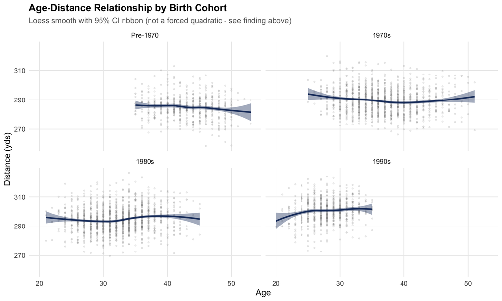

```r
p_age_distance <- df_3plus %>%
  filter(birth_cohort != "2000s+") %>%
  ggplot(aes(age, distance)) +
  geom_point(alpha = 0.15, size = 0.7, color = COL_NEUTRAL) +
  geom_smooth(method = "loess", color = COL_PRIMARY, fill = COL_PRIMARY) +
  facet_wrap(~birth_cohort) +
  labs(
    title    = "Age-Distance Relationship by Birth Cohort",
    subtitle = "Loess smooth with 95% CI ribbon (not a forced quadratic - see finding above)",
    x = "Age", y = "Distance (yds)"
  ) +
  THEME_BASE

p_age_distance
```

# 4. Peak Age Estimation

Reported honestly: the vertex formula is not reliable here, tested two ways.

```r
pooled_peak <- -age_coefs$estimate[age_coefs$term == "age_c"] / (2 * age_coefs$estimate[age_coefs$term == "age_c2"])
cat("Pooled vertex estimate (age_c units, centered at mean age", round(mean_age, 1), "):", round(pooled_peak, 1), "\n")
```

```
## Pooled vertex estimate (age_c units, centered at mean age 34.4 ): -36.6
```

```r
cohorts_present <- setdiff(levels(df_3plus$birth_cohort), "2000s+")

vertex_by_cohort <- map_dfr(cohorts_present, function(bc) {
  d <- df_3plus %>% filter(birth_cohort == bc)
  fit <- lmer(distance ~ age_c + age_c2 + (1 + age_c | player_name), data = d, control = lmerControl(optimizer = "bobyqa"))
  fe <- fixef(fit)
  tibble(birth_cohort = bc, age_c_coef = fe[["age_c"]], age_c2_coef = fe[["age_c2"]],
         vertex_age_c = -fe[["age_c"]] / (2 * fe[["age_c2"]]))
})

vertex_by_cohort %>% print()
```

```
## # A tibble: 4 x 4
##   birth_cohort age_c_coef age_c2_coef vertex_age_c
##   <chr>             <dbl>       <dbl>        <dbl>
## 1 Pre-1970         -0.476    -0.00302       -78.8
## 2 1970s            -0.480     0.0251          9.57
## 3 1980s             0.282     0.0168         -8.39
## 4 1990s             0.542    -0.00768        35.3
```

**Finding:** the per-cohort vertex estimates are physically implausible and inconsistent — `age_c2_coef` even flips sign between cohorts, and the implied vertex ages (in centered units) range from -78.8 to 35.3, nowhere close to a believable “peak age.” This formula should not be quoted as a real number from this data.

## 4.1 Nonparametric alternative: age at personal-best distance

```r
personal_peak <- df_3plus %>%
  filter(birth_cohort != "2000s+") %>%
  group_by(player_name, birth_cohort) %>%
  slice_max(distance, n = 1, with_ties = FALSE) %>%
  ungroup()

still_active <- df_3plus %>%
  filter(birth_cohort != "2000s+") %>%
  group_by(player_name, birth_cohort) %>%
  summarise(last_year = max(year), .groups = "drop") %>%
  mutate(active = last_year >= 2023)

peak_summary <- personal_peak %>%
  group_by(birth_cohort) %>%
  summarise(median_peak_age = median(age), n = n(), .groups = "drop") %>%
  left_join(still_active %>% group_by(birth_cohort) %>% summarise(pct_active = round(mean(active) * 100, 1), .groups = "drop"),
            by = "birth_cohort")

peak_summary %>% print()
```

```
## # A tibble: 4 x 4
##   birth_cohort median_peak_age     n pct_active
##   <fct>                  <dbl> <int>      <dbl>
## 1 Pre-1970                  42    91        0
## 2 1970s                     34   131       12.2
## 3 1980s                     33   154       47.4
## 4 1990s                     29   118       78.8
```

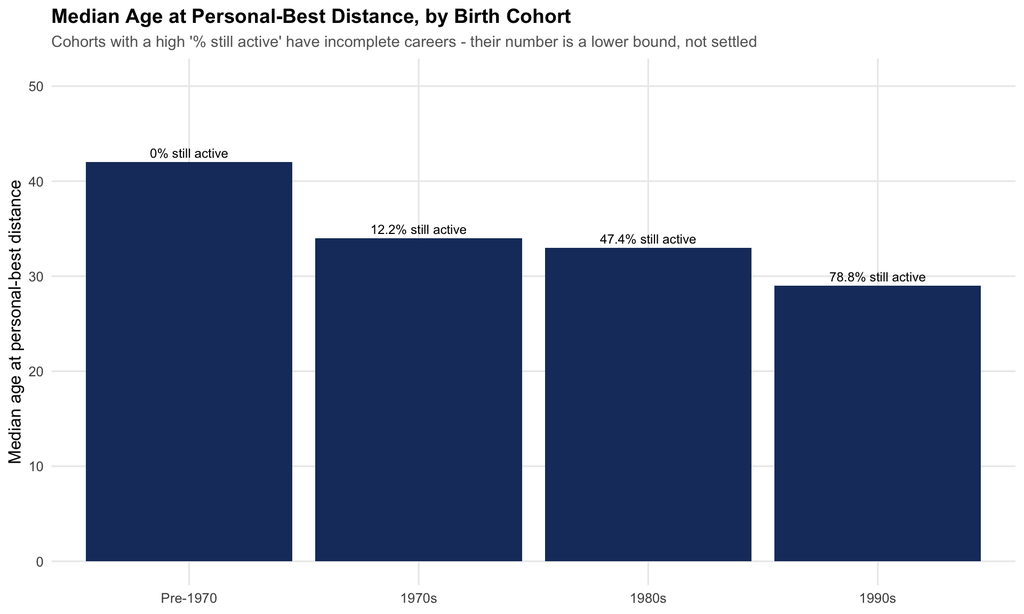

```r
p_personal_peak <- ggplot(peak_summary, aes(birth_cohort, median_peak_age)) +
  geom_col(fill = COL_PRIMARY) +
  geom_text(aes(label = paste0(pct_active, "% still active")), vjust = -0.5, size = 3.2) +
  labs(
    title    = "Median Age at Personal-Best Distance, by Birth Cohort",
    subtitle = "Cohorts with a high '% still active' have incomplete careers - their number is a lower bound, not settled",
    x = NULL, y = "Median age at personal-best distance"
  ) +
  THEME_BASE +
  ylim(0, max(peak_summary$median_peak_age) * 1.2)

p_personal_peak
```

**Finding:** median age-at-personal-best declines steadily by birth cohort — 42 (Pre-1970) → 29 (1990s) — but this is **not an apples-to-apples comparison**. Pre-1970’s careers are 0% still active (fully observed, reliable), while 1990s is 78.8% still active — most of that cohort hasn’t had the chance to record a new personal best in their 30s yet, so their number is a **lower bound** that will likely rise, not a settled finding.

# 5. Cohort Trajectory

Distance aligned by years-since-entry (`year - entry_year`, using the cross-referenced `entry_year` from `00_data_engineering.Rmd` — no rebuild needed), by `birth_cohort`.

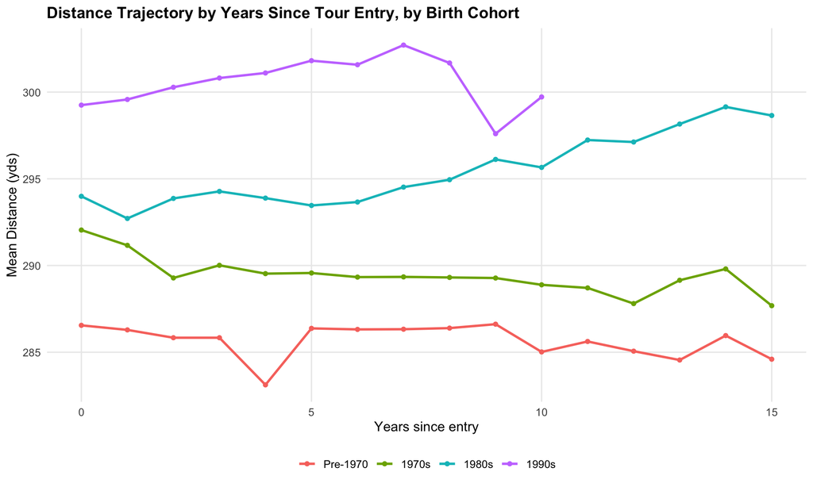

```r
cohort_traj <- df_3plus %>%
  filter(birth_cohort != "2000s+") %>%
  mutate(years_since_entry = year - entry_year) %>%
  filter(years_since_entry >= 0, years_since_entry <= 15) %>%
  group_by(birth_cohort, years_since_entry) %>%
  summarise(mean_distance = mean(distance), n = n(), .groups = "drop") %>%
  filter(n >= 5)

p_cohort_traj <- ggplot(cohort_traj, aes(years_since_entry, mean_distance, color = birth_cohort)) +
  geom_line(linewidth = 1) +
  geom_point() +
  labs(
    title = "Distance Trajectory by Years Since Tour Entry, by Birth Cohort",
    x = "Years since entry", y = "Mean Distance (yds)", color = NULL
  ) +
  THEME_BASE

p_cohort_traj
```

**Finding:** at the same career stage (years since entry), later-born cohorts sit at a higher distance level throughout — consistent with the field-wide rise documented in Project 1, now shown to hold at every common career stage, not just in aggregate.